# Novel Zillow Modelling Methodology

Sean Koh

2024-09-23

# 1 Introduction:

The geospatial data team have developed a new class of predictive model that has shown an approximate **7% improvement over currently implemented models**. The team believes that the model is compatible with our current processes and could translate to a **wider margin and more frequent sales**. In order to capitalize on this opportunities, the team is requesting a **budget increment of $50,000 for the coming quarter** in order to convert the prototype into a Minimum Viable Product (MVP).

# 2 Background:

Zillow’s housing valuation algorithm is the heart of the company’s value-adding process. We generate value by out-predicting the market through expertise and data-driven insights. Our signature “Zestimate” is the core product that keeps our customers coming back. Improving our Zestimate is key to customer loyalty, sales profit margins, and our major growth driver. (“What Is a Zestimate?” n.d.)

# 3 The Current Valuation Process

Our current algorithm studies the features of the house (e.g. Livable area, number of bedrooms, etc.) and the location (quantified by the U.S. Census Tract). All the variables are computed within our proprietary “Zestimate” equation.

However, we were recently made aware of large losses occurring in Philadelphia. To visualize the losses, we plotted our current model’s prediction of prices in Philadelphia against the actual sales prices in 2022-2023.

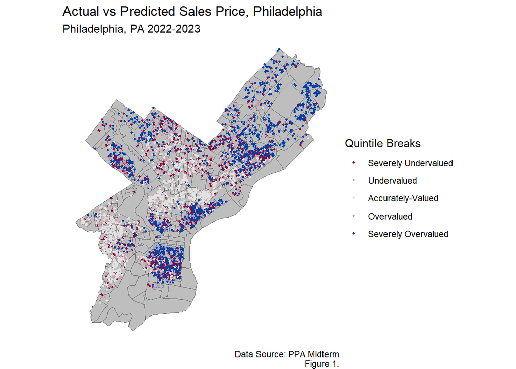

# 4 New proposed approach

However, we have developed a new method to update our existing predictions and correct for these spatial patterns. This new methodology applies a 3-step process to extract pricing information from location.

Firstly, we map the location data of historical sales onto a honeycomb grid. This will let our algorithm read the sales data like an image, allowing us to seperate the map into distinct “zones” that share similar neighbourhood characteristics.

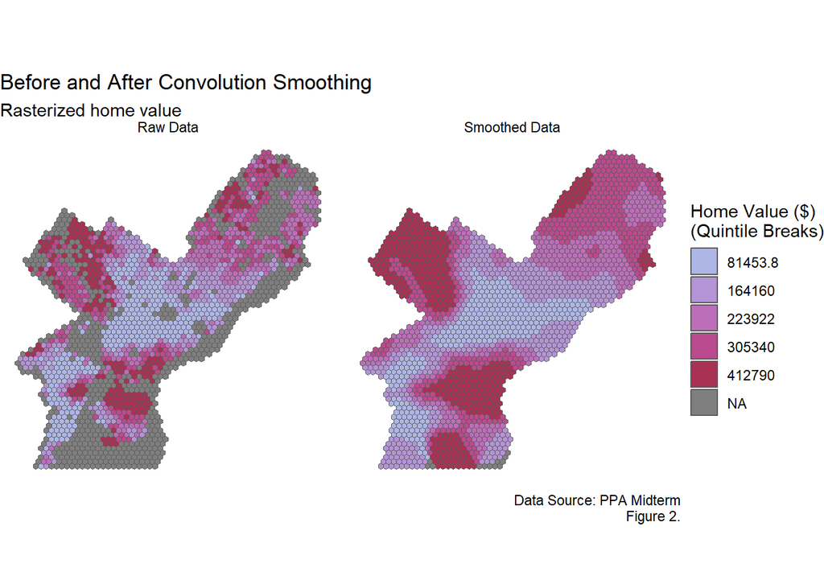

Secondly, we smooth out the grid through a process known as convolution. Broadly, this will help to get rid of “noise” in a manner similar to clarifying a blurry picture.

Finally, we divide the city area into zones based on the price values from the smoothed out grid. Ideally, these zones will convey important price signals about how the location of the home determines the valuation. A significant improvement of this new model over the current one is that we are not bound by the shape of census tracts.

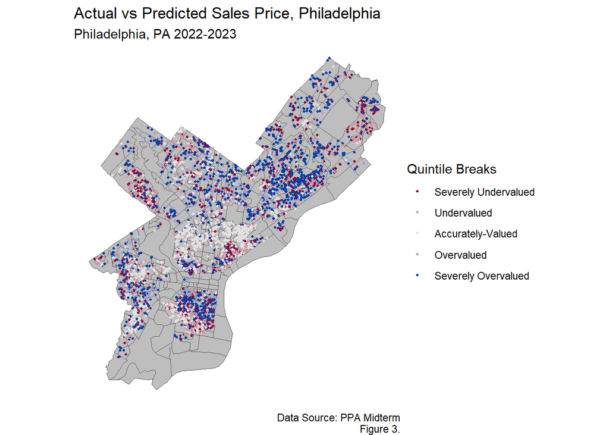

# 5 Conclusion

The new proposed model improves the Mean Abosolute Percentage Error (MAPE) from 77.4 to 70.3. We also can observe a large reduction in overvaluations in the downtown area, with a minor increase in overvaluations in North Philadelphia.

Overall, the new model still requires tuning and improvements before it can be implemented in production. Key areas to study are how the model affects different home types, where its biases lie, and how we can continue to improve upon it.

# 6 References

In order to continue research on this model, we are thus requesting an expanded budget in order to bring in new team members to iterate on the current model.

“What Is a Zestimate?” n.d. https://www.zillow.com/z/zestimate/.